# Biodiversity consequences of land-use change and forest disturbance in the Amazon: A multi-scale assessment using ant communities - ScienceDirect

[Advanced](https://www.sciencedirect.com/search)

## Figures (6)

[figure not shown]

[figure not shown]

[figure not shown]

## Extras (1)

1. Supplementary material.

## [Biological Conservation](https://www.sciencedirect.com/science/journal/00063207)

[Volume 197](https://www.sciencedirect.com/science/journal/00063207/197/supp/C), May 2016, Pages 98-107

# Biodiversity consequences of land-use change and forest disturbance in the Amazon: A multi-scale assessment using ant communities

[Ricardo Ribeiro de CastroSolar<sup>a</sup><sup>b</sup><sup>c</sup>](https://www.sciencedirect.com/science/article/pii/S0006320716300830?via%3Dihub#!)[JosBarlow<sup>c</sup><sup>d</sup>](https://www.sciencedirect.com/science/article/pii/S0006320716300830?via%3Dihub#!)[Alan N.Andersen<sup>e</sup>](https://www.sciencedirect.com/science/article/pii/S0006320716300830?via%3Dihub#!)[José H.Schoereder<sup>f</sup>](https://www.sciencedirect.com/science/article/pii/S0006320716300830?via%3Dihub#!)[ErikaBerenguer<sup>c</sup>](https://www.sciencedirect.com/science/article/pii/S0006320716300830?via%3Dihub#!)[Joice N.Ferreira<sup>g</sup>](https://www.sciencedirect.com/science/article/pii/S0006320716300830?via%3Dihub#!)[Toby AlanGardner<sup>h</sup>](https://www.sciencedirect.com/science/article/pii/S0006320716300830?via%3Dihub#!)

https://doi.org/10.1016/j.biocon.2016.03.005[Get rights and content](https://s100.copyright.com/AppDispatchServlet?publisherName=ELS&contentID=S0006320716300830&orderBeanReset=true)

Under a Creative Commons [license](https://creativecommons.org/licenses/by/4.0/)

open access

## Highlights

**•**

Ants were sampled over multiple landscapes and land-uses at a deforestation frontier.

**•**

Forest areas supported almost twice as many species as production areas.

**•**

Total landscape richness increases with the proportion of remaining primary forest.

**•**

Species composition varied consistently across a gradient of aboveground biomass.

**•**

Disturbed forests have an impoverished ant fauna but remain vital for conservation.

## Abstract

Quantifying and understanding the main drivers of biodiversity responses to human disturbances at multiple scales is key to foster effective conservation plans and management systems. Here we report on a detailed regional assessment of the response of ant communities to land-use change and forest disturbance in the Brazilian Amazon. We aimed to explore the effects of land-use intensification at both site and landscape scales, examining variation in ant species richness and composition, and asking which set of environmental variables best predict observed patterns of diversity. We sampled 192 sites distributed across 18 landscapes (each 50 km<sup>2</sup>) in Paragominas, eastern Brazilian Amazon, covering ca. 20,000 km<sup>2</sup>. We sampled from undisturbed [primary forest](https://www.sciencedirect.com/topics/agricultural-and-biological-sciences/primary-forests) through varyingly disturbed primary forests, [secondary forests](https://www.sciencedirect.com/topics/agricultural-and-biological-sciences/secondary-forests), pastures and mechanised agriculture, following a gradient of decreasing total [aboveground biomass](https://www.sciencedirect.com/topics/earth-and-planetary-sciences/aboveground-biomass). Irrespective of forest disturbance class, ant species richness was almost twice as high in forests when compared to production areas. In contrast, ant species composition showed continuous variation from primary forest to intensive agriculture, following a gradient of aboveground biomass. Ant species richness at all spatial scales increased with primary forest cover in the surrounding landscapes. We highlight the limited value of species richness as an indicator of changes in habitat quality, reinforcing calls to consider species composition in assessments of forest disturbance. Taken together, our results reveal the unique biodiversity value of undisturbed primary forests, but also show that disturbed primary forests and secondary forests have high conservation value, and thus play an important role in regional conservation planning.

## Keywords

Biodiversity conservation

Forest degradation

Formicidae

Human-modified

Invertebrates

Rainforest

## 1. Introduction

Human-induced changes to the biosphere have led to widespread biodiversity loss across the planet (Gibson et al., 2011; Newbold et al., 2015). Tropical forests are at the forefront of conservation concerns as, despite harbouring two-thirds of global terrestrial biodiversity (Slik et al., 2015), they remain subject to high levels of deforestation, fragmentation, and selective logging, among other impacts (Malhi et al., 2014). As a result, much of the remaining areas of tropical forests are embedded within human-modified landscapes containing different land-use systems, including a variety of agricultural lands and areas of standing forests that have experienced different levels of anthropogenic disturbance (Gardner et al., 2009). Despite extensive research on the impacts of particular land-use changes on biodiversity (e.g. Coronado et al., 2009; Karp et al., 2012), we still know very little about biodiversity persistence within such heterogeneous landscapes.

Our current understanding of biodiversity responses to and forest disturbance change in tropical forests regions is limited by some methodological limitations of past studies. First, many studies have examined only highly contrasting land uses — e.g. forests versus agriculture (e.g. Azevedo-Ramos et al., 2006; Dexter et al., 2012). Second, few studies comprehensively document environmental variables that could be used to understand factors promoting biodiversity persistence in different land-use systems (but see Carrara et al., 2015). Third, despite growing indications that landscape-level attributes (e.g. area of remaining forest cover) can have an important influence on local patterns of biodiversity (Solar et al., 2015), most studies continue to only be conducted at the local (site) scale without appropriate reference to broader landscape conditions (Tabarelli et al., 2012). Finally, the vast preponderance of biodiversity studies in human-modified tropical forests have focused on plants and vertebrates (e.g. Antongiovanni and Metzger, 2005; Dexter et al., 2012), yet we know that invertebrates comprise most species and they often respond differently to human-induced disturbances (Andersen and Majer, 2004; Barlow et al., 2007a; Solar et al., 2015).

Arthropods are by far the most numerically dominant faunal group in tropical environments, and play critically important roles in ecosystem functioning (Hamilton et al., 2010). Among the arthropods, ants are a ubiquitous group, dominating faunal biomass in many forests (Hölldobler and Wilson, 2009; Basset et al., 2015), occupying all forest strata (Blüthgen and Feldhaar, 2010), and playing a wide variety of key functional roles relating to soil health, nutrient cycling, energy flow, herbivory and [seed dispersal](https://www.sciencedirect.com/topics/earth-and-planetary-sciences/seed-dispersal) (Del Toro et al., 2012). Moreover, ants have been widely used as bioindicators of human disturbance (Andersen and Majer, 2004). Yet despite their importance, very few studies have assessed responses of tropical forest ant communities to human disturbance at large spatial scales, such as those comprising several hundreds of kilometres (but see Vasconcelos et al., 2006; Vasconcelos et al., 2010; Leal et al., 2012 for exceptions), and, to our knowledge, none across multiple-use human-modified landscapes.

Here we examine the implications of human-modified tropical forests and land-use change for Amazonian ant assemblages, focussing on the importance of [forest habitats](https://www.sciencedirect.com/topics/agricultural-and-biological-sciences/forest-habitats) for the [conservation of species](https://www.sciencedirect.com/topics/earth-and-planetary-sciences/conservation-of-species) at local and regional scales. We report on an assessment of ant communities sampled from 192 transects distributed across eighteen 50-km<sup>2</sup> catchments in a large (ca. 20,000 km<sup>2</sup>) human-modified region of the eastern Brazilian Amazon. We address two specific questions. First, how does ant species richness and composition vary with land-use change and forest disturbance (from undisturbed forest, through varying degrees of forest disturbance and production areas) at site and landscape scales? Second, what set of environmental variables best predict observed patterns of species richness and composition at both site and landscape scales? We also identify ant species that are strongly associated with different land-uses and therefore could be used as valuable indicators of the ecological consequences of human disturbance. Taken together, these analyses provide a quantitative understanding of the environmental drivers of maintenance and loss of ant communities in one of the most species-rich areas of the planet, and can help provide a basis for predicting the biodiversity consequences of future land-use change and forest disturbance.

## 2. Materials and methods

### 2.1. Study region

We conducted our study in Paragominas, a municipality located in the eastern Brazilian Amazon, in the state of Pará (Fig. 1). Paragominas was originally covered with evergreen tropical forest, but has experienced circa 35% forest loss and widespread degradation of remaining forests in recent decades, especially due to forest conversion to pastures and mechanised agriculture, and degradation by selective logging, fragmentation and understory fires (for more details, see Gardner et al., 2013; Viana et al., 2016).

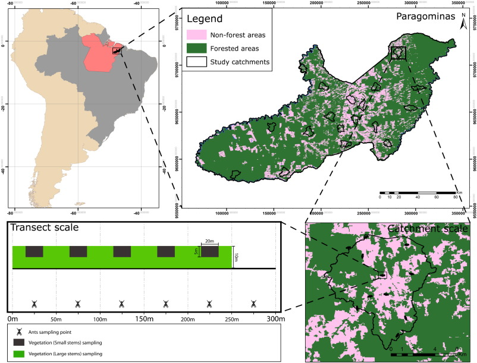

1. [Download : Download high-res image (1MB)](https://ars.els-cdn.com/content/image/1-s2.0-S0006320716300830-gr1_lrg.jpg)
2. [Download : Download full-size image](https://ars.els-cdn.com/content/image/1-s2.0-S0006320716300830-gr1.jpg)

Fig. 1. Map of Paragominas municipality and an overview of the sampling design at both catchment and transect scales.

We sampled two major land-use categories, divided into seven classes: production areas (3 classes) and forests (4 classes). Production areas comprised mechanised agriculture (N = 14), cattle pastures (N = 50), and silviculture (monocultures of *Eucalyptus* spp. and *Schyzolobium parahyba* var. *amazonicum*, N = 12). Forest classes comprised [secondary forests](https://www.sciencedirect.com/topics/agricultural-and-biological-sciences/secondary-forests) (N = 20), logged and burnt [primary forests](https://www.sciencedirect.com/topics/agricultural-and-biological-sciences/primary-forests) (N = 44), logged primary forests (N = 43) and undisturbed primary forests (N = 9). Forest classification was based on systematic field observations of evidence of past human disturbance, such as charcoal and logged stumps, combined with a visual analysis of a 20-year chronosequence of satellite images (Gardner et al., 2013).

### 2.2. Sampling design

We used ArcGIS 10 to divide Paragominas into 182 roughly evenly sized third- or fourth-order catchments (ca. 50 km<sup>2</sup> each — landscape scale), from which we selected 18 for biodiversity surveys that were distributed across a gradient of remaining forest cover (6–100%). Within each landscape, we allocated 8–12 transects (each 300 m — site scale) at a standard density of 1 transect/4 km<sup>2</sup>, separated by at least 1.5 km. The number of sites allocated to each land-use class was proportional to the overall area occupied by either production areas or forests within a catchment. In total, we sampled 192 transects over an area of approximately 20,000 km<sup>2</sup> (Fig. 1; detailed information can be found in Gardner et al., 2013).

Along each site we installed six epigaeic baited [pitfall traps](https://www.sciencedirect.com/topics/earth-and-planetary-sciences/pitfall-trap) spaced by 50 m that operated for a 48-h period. Traps consisted of plastic containers (10 cm diam.) half filled with a solution of water, salt (5%) and soap (5%), and baited with [sardine](https://www.sciencedirect.com/topics/agricultural-and-biological-sciences/sardines) and honey, which were placed in a cup hanging above the plastic containers that was unreachable to the ants. After sampling, we identified the ants using available [taxonomic keys](https://www.sciencedirect.com/topics/agricultural-and-biological-sciences/taxonomic-keys) (e.g. Fernández, 2003; Baccaro et al., 2015) and the reference collection of the [Community Ecology](https://www.sciencedirect.com/topics/earth-and-planetary-sciences/community-ecology) Lab, Federal University of Viçosa. Species nomenclature was checked and revised against Bolton's online catalogue (Bolton; http://antcat.org, accessed in Feb/2016). [Morphospecies](https://www.sciencedirect.com/topics/agricultural-and-biological-sciences/morphospecies) were assigned number codes that apply only to this study. A full collection of voucher specimens is housed at Community Ecology Lab, Universidade Federal de Viçosa.

### 2.3. Environmental variables

Table 1. Details of the environmental variables sampled in this study. Further details of sampling methodologies and techniques adopted are described in Gardner et al. (2013).

| Variable sampled | Acronym | Proxy for | Scale of sampling | Summary sampling methodology |
| --- | --- | --- | --- | --- |
| Total above ground biomass (Mg·ha<sup>− 1</sup>) | AGB | Land-use intensification | Transect | Aboveground biomass was based on field measurements and allometric equations. |
| Fine woody debris biomass (Mg·ha<sup>− 1</sup>) | FWD | Nesting resources | Transect | Fine woody debris consisting of fragments between 2 and 10 cm diameter were sampled in five 2 × 5 m sections. |
| Litter biomass (Mg·ha<sup>− 1</sup>) | LB | Habitat conditions and resources | Transect | Paired leaf litter samples were taken every 50 m along the transect using 50 × 50 cm quadrats. |
| Tree species richness | TSR | Habitat conditions and resources | Transect | All trees and palms ≥ 10 cm DBH were identified in 10 × 250 m plots. Smaller individuals (2–9.99 cm diameter) were sampled in five subplots of 5 × 20 m. |
| Primary forest cover (%) | PFP | Forest condition | 500 m buffer around each transect and catchment | Satellite imagery (LANDSAT) was used to determine the percentage primary forest cover in a 500 m buffer surrounding each transect. |
| Canopy cover (%) | CC | Habitat conditions | Transect | In each transect, five hemispherical photos were taken at a 50 m interval. |
| Soil bulk density (g·cm<sup>− 3</sup>) | SBD | Soil conditions | Transect | Calculated by the volumetric cylinder method |
| Clay content (%) | CP | Soil conditions | Transect | Soil granulometric determination, using the densimeter method |
| Deforestation trajectory | FCCP | Land-use history | 500 m buffer around each transect and catchment | Forest change curvature profile, calculated by the LUCAT tool for ArcGIS (Ferraz et al., 2009) |

### 2.4. Statistical analyses

We adopted total aboveground biomass (see Table 1) as a proxy for characterising a continuous gradient of land-use intensification and forest disturbance (Grime, 1979). Aboveground biomass is sensitive to multiple [human impacts](https://www.sciencedirect.com/topics/earth-and-planetary-sciences/anthropogenic-effect) on forests in our sites (Berenguer et al., 2014), and is therefore a measure of their combined impact. All forest classes were significantly different with regard to AGB at the site scale (χ<sup>2</sup><sub>6,11</sub> = 513.2, *P* < 0.001, R<sup>2</sup> = 0.93, Fig. S1), but pasture and mechanised agriculture were indistinguishable from each other because of either the scarcity or total lack of trees.

To assess the relationship between ant species richness and land-use class at the site scale, we used Generalized Linear Mixed Model (GLMM, Bolker et al., 2009) with land-use class as the explanatory variable and landscape identity as the random factor. We then submitted the seven land-use classes to a contrast analysis, combining statistically similar classes (Crawley, 2012).

Comparisons of regional diversity among land-use classes could be potentially biased by variation in the number of samples (sites), which ranged from nine (undisturbed primary forests) to 50 (pastures). To circumvent this issue, we developed extrapolated sample-based rarefaction curves for up to 50 samples for all land-use classes. We then compared richness from a rarefied n = 9 transects, as well as extrapolated values, acknowledging that extrapolation beyond three-times the sample size can be unreliable (Colwell et al., 2012). Extrapolations were done considering presence/absence data (Hill numbers of order 0) and incidence data (Hill numbers of order 1), thus reducing a potential bias caused by rarely sampled species (Chao et al., 2014). We considered non-overlapping standard error estimates as having accumulated different number of species.

To examine variation in species composition at the site scale, we used non-metric multidimensional scaling (NMDS) of individual transects, using presence/absence data and the Jaccard's dissimilarity index. We first visually examined the extent to which there was landscape-scale spatial structure in the ordination, and then we used PERMANOVA to test for significant clustering of sites with respect to different land-use classes and across the gradient of AGB. We computed 999 permutations, stratified within catchments, to account for the hierarchical sampling design (i.e. sites placed within landscapes). To account for known limitations of PERMANOVA (Warton et al., 2012), we also ran *mvabund* Generalized Linear Models (with negative binomial distribution) tests, using AGB as the explanatory variable. As both methods yielded very similar results, we opted to show only those from PERMANOVA. We computed indicator values (IndVal, Dufrene and Legendre, 1997) for each species in relation to their distribution in each of the seven land-use classes. The significance of IndVal indices was assessed using 10,000 Monte Carlo permutations.

Finally, we examined the effects of the environmental variables (Table 1) on species richness at both the site and landscape scales, as well as their effects on species composition at the site scale as measured by the first axis of a PCoA ordination, which catches most of the land-use variation (accounting for 19% of variation, Fig. S2). To do so, we used multi-model inference, based on a global model with all candidate variables followed by model selection (Burnham et al., 2011). We evaluated relative model performance based on AICc and selected the best set of models among all possibilities derived from global models via multimodel inference (Burnham et al., 2011). From the complete set of possible models, we averaged coefficients of all models within ΔAICc < 4, thus capturing greater uncertainty in the final set of candidate variables (Vierling et al., 2013). The model containing all variables retained in the candidate set was subjected to hierarchical partitioning, that then computes the independent contribution of each variable in order to assess their relative importance (Mac Nally, 2000; Murray and Conner, 2009).

At the site scale, we built models with richness per site and 1st PCOa axis as the response variable and we analysed separately forest and non-forest areas. At the landscape scale, the response variable was the rarefied number of species within a catchment for all transects within it, regardless of land-use class. The rarefied number was the average species richness for nine transects (the minimum number of sites within a landscape) after 10,000 resampling runs. To get comparable [regression coefficients](https://www.sciencedirect.com/topics/earth-and-planetary-sciences/regression-coefficient), we standardised all variables by the maximum value (ranging between 0 and 1). Repeating analyses with non-standardised variables values generated the same set of best-performing models with the same variables.

Whenever the response variable was count data (e.g. species richness), we used [Poisson distribution](https://www.sciencedirect.com/topics/agricultural-and-biological-sciences/poisson-distribution), corrected for over-dispersion if required. Distribution suitability and model fit were checked via residual analyses (Crawley, 2012). We performed all analyses in the platform R (R-Core-Team, 2015). We used the following packages for computing: 1) Ordinations and PERMANOVA — *vegan*; 2) IndVal — *labdsv*; 3) GLM tests for species composition — *mvabund*; 4) sample-based extrapolation curves — *iNEXT*; 5) GLMM — *lme4*; 6) model selection — *MuMIn* and 7) hierarchical partitioning — *hier.part*.

## 3. Results

### 3.1. The ant fauna

In total, we recorded 282 ant species from 56 genera and ten subfamilies. *[Pheidole](https://www.sciencedirect.com/topics/agricultural-and-biological-sciences/pheidole)* was both the most frequently recorded genus and the one with the largest number of sampled species (65 species, in 80% of traps), followed by *[Solenopsis](https://www.sciencedirect.com/topics/agricultural-and-biological-sciences/solenopsis)* (26 species, in 75% of traps). The most frequently recorded ant species were *[Wasmannia auropunctata](https://www.sciencedirect.com/topics/agricultural-and-biological-sciences/wasmannia-auropunctata)* (Roger, 1863) (present in 26% of traps) and *Ectatomma brunneum* Smith, 1858 (25% of traps).

### 3.2. Site and landscape ant species richness in different land-use classes

Species richness at the site scale was significantly higher in forests (mean = 26, SE = 2.42) than in production areas (mean = 16.6, SE = 1.9, χ<sup>2</sup><sub>(16)</sub> = 104.97, *P* < 0.001, Fig. 2A), but did not vary within forest classes (χ<sup>2</sup><sub>(16)</sub> = 0.04, *P* = 0.83). Within production areas, pastures were not different from silvicultural areas (mean = 17.5, SE = 2.21, χ<sup>2</sup><sub>(16)</sub> = 0.961, *P* = 0.32), but were richer than arable fields (mean = 13, SE = 3.45, χ<sup>2</sup><sub>(16)</sub> = 11.31, *P* < 0.001, Fig. 2A).

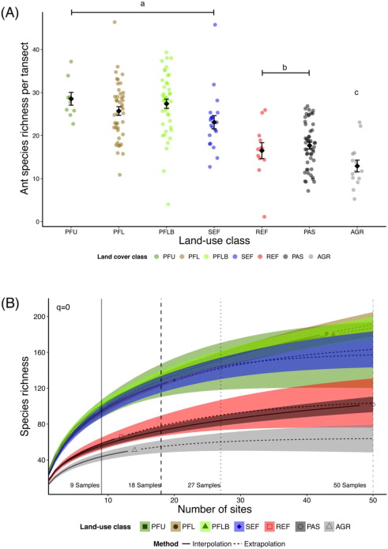

1. [Download : Download high-res image (407KB)](https://ars.els-cdn.com/content/image/1-s2.0-S0006320716300830-gr2_lrg.jpg)
2. [Download : Download full-size image](https://ars.els-cdn.com/content/image/1-s2.0-S0006320716300830-gr2.jpg)

Fig. 2. Relationship between species richness and land-use class at (A) the transect scale; and b) considering species accumulation curves with extrapolated values per land-use for presence/absence. Land-uses grouped underneath the same letter are statistically similar (*P* > 0.05). Dashed lines represent the number of sites sampled. Vertical lines are representing the minimum sampling effort (nine sites) and extrapolated to 18 (doubled); 27 (tripled) and 50 sites (maximum). Shaded polygons around each curve represent 95% confidence intervals. PFU — undisturbed [primary forest](https://www.sciencedirect.com/topics/agricultural-and-biological-sciences/primary-forests); PFL — logged primary forest; PFLB — logged and burnt primary forest; SEF — [secondary forests](https://www.sciencedirect.com/topics/agricultural-and-biological-sciences/secondary-forests); REF — silviculture; PAS — pastures; AGR — mechanised agriculture.

We found similar results in species richness at the landscape-scale. Forests (irrespective of disturbance class) accumulated similar number of species, but held almost twice as many species as pastures and silviculture (147 ± 10.9 vs. 84 ± 8.4 species, extrapolating richness to 27 samples, Fig. 2B), while agriculture was the most species-poor land use (51 ± 5.8 species). These results were consistent for both presence–absence and abundance data (Fig. S3).

### 3.3. Species composition across the human impact gradient

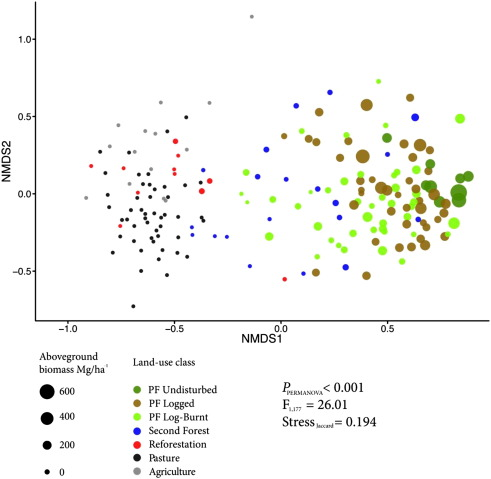

1. [Download : Download high-res image (238KB)](https://ars.els-cdn.com/content/image/1-s2.0-S0006320716300830-gr3_lrg.jpg)
2. [Download : Download full-size image](https://ars.els-cdn.com/content/image/1-s2.0-S0006320716300830-gr3.jpg)

Fig. 3. NMDS plot of species composition according to [aboveground biomass](https://www.sciencedirect.com/topics/earth-and-planetary-sciences/aboveground-biomass) (point sizes) and land-use types (point colours). PFU — undisturbed [primary forest](https://www.sciencedirect.com/topics/agricultural-and-biological-sciences/primary-forests); PFL — logged primary forest; PFLB — logged and burnt primary forest; SEF — [secondary forests](https://www.sciencedirect.com/topics/agricultural-and-biological-sciences/secondary-forests); REF — silviculture; PAS — pastures; AGR — mechanised agriculture.

Table 2. Indicator species of each land-use class according IndVal analyses. In the table, only significant indicator species are shown. PFU — undisturbed [primary forest](https://www.sciencedirect.com/topics/agricultural-and-biological-sciences/primary-forests); PFL — logged primary forest; PFLB — logged and burnt primary forest; SEF — [secondary forests](https://www.sciencedirect.com/topics/agricultural-and-biological-sciences/secondary-forests); REF — silviculture; PAS — pastures; AGR — mechanised agriculture.

| Species | Land-use class | IndVal | *P*-value |
| --- | --- | --- | --- |
| *Crematogaster tenuicula* | PFU | 0.6515 | 0.001 |
| *Pheidole* sp.4 | PFU | 0.5159 | 0.001 |
| *Gnamptogenys striatula* | PFU | 0.4846 | 0.001 |
| *Pheidole* sp.6 | PFU | 0.468 | 0.001 |
| *Ectatomma lugens* | PFU | 0.3691 | 0.005 |
| *Pachycondyla harpax* | PFU | 0.3473 | 0.015 |
| *Pachycondyla crassinoda* | PFU | 0.3319 | 0.016 |
| *Nylanderia* sp.3 | PFU | 0.3156 | 0.009 |
| *Nylanderia* sp.7 | PFU | 0.3055 | 0.007 |
| *Solenopsis* sp.8 | PFU | 0.2985 | 0.006 |
| *Pheidole* sp.25 | PFU | 0.2613 | 0.016 |
| *Gnamptogenys moelleri* | PFU | 0.2512 | 0.03 |
| *Pheidole* sp.12 | PFU | 0.244 | 0.009 |
| *Pheidole* sp.16 | PFU | 0.2373 | 0.016 |
| *Pheidole* sp.47 | PFU | 0.2016 | 0.007 |
| *Pheidole* sp.3 | PFU | 0.2012 | 0.015 |
| *Gnamptogenys horni* | PFU | 0.1894 | 0.021 |
| *Solenopsis* sp.5 | PFU | 0.1468 | 0.035 |
| *Solenopsis* sp.13 | PFL | 0.3104 | 0.029 |
| *Sericomyrmex* sp.1 | PFLB | 0.3111 | 0.019 |
| *Odontomachus bauri* | PFLB | 0.2093 | 0.041 |
| *Linepithema neotropicum* | PFLB | 0.1916 | 0.025 |
| *Atta cephalotes* | PFLB | 0.1364 | 0.049 |
| *Solenopsis geminata* | SEF | 0.4084 | 0.002 |
| *Pheidole* sp.1 | SEF | 0.3159 | 0.025 |
| *Camponotus* sp.8 | SEF | 0.2937 | 0.006 |
| *Solenopsis invicta* | SEF | 0.2751 | 0.02 |
| *Nylanderia* sp.2 | SEF | 0.269 | 0.031 |
| *Brachymyrmex* sp.2 | SEF | 0.2605 | 0.002 |
| *Pheidole* sp.58 | SEF | 0.26 | 0.012 |
| *Ectatomma brunneum* | SEF | 0.2486 | 0.025 |
| *Camponotus senex* | SEF | 0.23 | 0.007 |
| *Camponotus renggeri* | SEF | 0.1586 | 0.048 |
| *Crematogaster erecta* | SEF | 0.1531 | 0.027 |
| *Camponotus blandus* | SEF | 0.1419 | 0.017 |
| *Pheidole* sp.35 | SEF | 0.1 | 0.039 |
| *Pseudomyrmex termitarius* | PAS | 0.64 | 0.001 |
| *Camponotus senex* | PAS | 0.46 | 0.003 |
| *Nylanderia* sp.4 | PAS | 0.45 | 0.005 |
| *Wasmannia auropunctata* | PAS | 0.39 | 0.046 |
| *Dorymyrmex* sp.1 | REF | 0.39 | 0.002 |
| *Pheidole* sp.34 | REF | 0.38 | 0.003 |
| *Odontomachus bauri* | REF | 0.28 | 0.035 |
| *Cardiocondyla emeryi* | REF | 0.24 | 0.006 |
| *Atta sexdens* | AGR | 0.24 | 0.018 |

### 3.4. Environmental predictors of ant species richness and composition

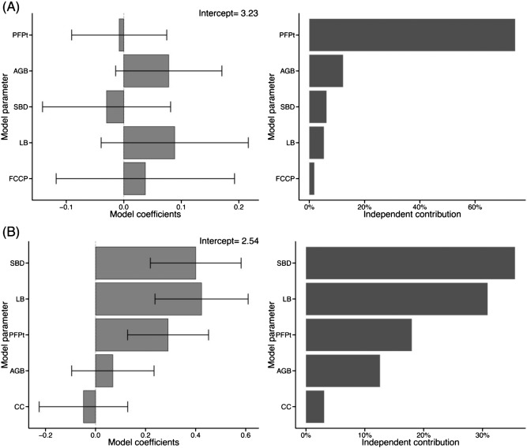

1. [Download : Download high-res image (362KB)](https://ars.els-cdn.com/content/image/1-s2.0-S0006320716300830-gr4_lrg.jpg)
2. [Download : Download full-size image](https://ars.els-cdn.com/content/image/1-s2.0-S0006320716300830-gr4.jpg)

Fig. 4. Model averaging of candidate models within ΔAICc < 4 for transect scale species richness showing (A) forest transects and (B) production landscapes. All averaged coefficients (± standard errors) are shown on the left side, relative importance values (RIV) are shown on the right side. AGB — [aboveground biomass](https://www.sciencedirect.com/topics/earth-and-planetary-sciences/aboveground-biomass), CC — canopy cover, FWD — fine wood debris, LB — litter biomass, PFP(t) — percentage of [primary forest](https://www.sciencedirect.com/topics/agricultural-and-biological-sciences/primary-forests) surrounding each transect, SBD — soil bulk density, FCCP(t) — deforestation trajectory at transect scale, LUC — land-use class, df — degrees of freedom.

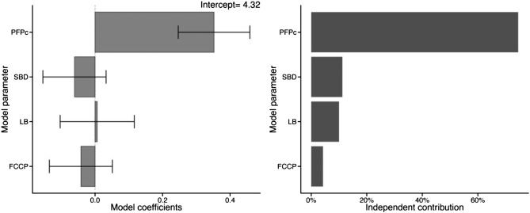

1. [Download : Download high-res image (158KB)](https://ars.els-cdn.com/content/image/1-s2.0-S0006320716300830-gr5_lrg.jpg)
2. [Download : Download full-size image](https://ars.els-cdn.com/content/image/1-s2.0-S0006320716300830-gr5.jpg)

Fig. 5. Model averaging results for [catchment scale](https://www.sciencedirect.com/topics/earth-and-planetary-sciences/catchment-scale) species richness. All averaged coefficients (± standard errors) are shown on the left side, relative importance values (RIV) are shown on the right side. AGB — [aboveground biomass](https://www.sciencedirect.com/topics/earth-and-planetary-sciences/aboveground-biomass), PFP(c) — percentage of [primary forest](https://www.sciencedirect.com/topics/agricultural-and-biological-sciences/primary-forests) in each catchment, SBD — soil bulk density, FCCP — deforestation trajectory.

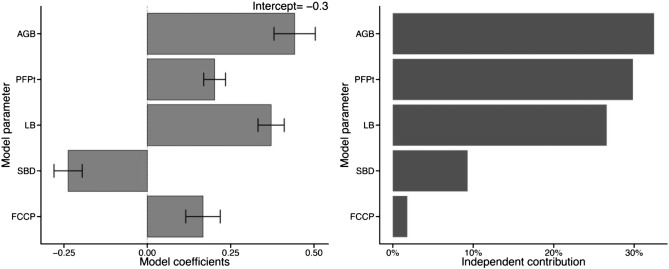

1. [Download : Download high-res image (178KB)](https://ars.els-cdn.com/content/image/1-s2.0-S0006320716300830-gr6_lrg.jpg)
2. [Download : Download full-size image](https://ars.els-cdn.com/content/image/1-s2.0-S0006320716300830-gr6.jpg)

Fig. 6. Model averaging results for species composition analyses based on the first NMDS axis. All averaged coefficients (± standard errors) are shown on the left side, relative importance values (RIV) are shown on the right side. Error bars represent standard error. AGB — [aboveground biomass](https://www.sciencedirect.com/topics/earth-and-planetary-sciences/aboveground-biomass), PFP(t) — percentage of [primary forest](https://www.sciencedirect.com/topics/agricultural-and-biological-sciences/primary-forests) surrounding each transect, SBD — soil bulk density, FCCP — deforestation trajectory.

## 4. Discussion

We have presented the first detailed regional assessment of the response of ant communities to land-use change and forest disturbance for a tropical forest region. Our primary objectives were to assess the effects of land-use intensification at both site and landscape scales, and to identify the environmental variables that best predict patterns of diversity, providing novel insights into the environmental drivers of biodiversity responses to land-use changes in tropical forests.

### 4.1. Ant responses to land-use change and forest disturbance

We found a contrast in ant species richness between forests (high values) and production areas (low values) at both site and landscape scales, with mechanised agricultural sites having the fewest species. These findings are consistent with previous studies of the biodiversity impacts of intensive land use (Ricketts et al., 2001; Goehring et al., 2002; Chan and Daily, 2008), and reinforce the negative impact of deforestation on ant diversity (Yates and Andrew, 2011; Kuate et al., 2015), as well as the diversity of other invertebrates, vertebrates and plants (Vasconcelos and Bruna, 2012; Moura et al., 2013; Ochoa-Quintero et al., 2015). Our results also support previous findings that disturbed [primary and secondary forests](https://www.sciencedirect.com/topics/agricultural-and-biological-sciences/primary-forests) can hold high numbers of species (Vasconcelos, 1999; Arroyo-Rodríguez et al., 2015; Solar et al., 2015). However, as in studies on other taxa, we recognise that the high species richness of disturbed forests might be inflated by ‘spillover’ from undisturbed forest (Gardner et al., 2009; Tabarelli et al., 2012), and that our standardised sampling could underestimate the richness of undisturbed forests.

In contrast to richness, ant species composition showed continuous variation across land-use classes, from undisturbed primary forest to intensive agriculture, measured by a gradient of [aboveground biomass](https://www.sciencedirect.com/topics/earth-and-planetary-sciences/aboveground-biomass). While many previous studies describe pair-wise compositional differences between different land-use or forest classes (e.g. Wilkie et al., 2009), our study is the first to demonstrate a continuum of compositional change along a full disturbance gradient. This illustrates the limited value of species richness as an indicator of changes in habitat quality, and our results reinforce calls to consider species composition and community turnover when assessing the impacts of forest disturbance (Su et al., 2004; Barlow et al., 2007a). Variation in species composition is also important from a functional perspective, given that different species play different roles in ecosystems (Folgarait, 1998; Del Toro et al., 2012), such that compositional change can affect important ecosystem functions (Bihn et al., 2010).

The unique composition of undisturbed primary forest highlights the importance of conserving such habitats, supporting conclusions of other authors studying ants (Vasconcelos et al., 2000; Vasconcelos et al., 2006), other insect groups (Barlow et al., 2007b; Barlow et al., 2008), as well as vertebrates and plants (Barlow et al., 2007a; Gardner et al., 2007; Moura et al., 2013). The high value of undisturbed primary forests was also supported by our indicator species analysis. We identified 18 ant species that are significant indicators of undisturbed primary forest, and are therefore especially sensitive to disturbance. These species included specialist predators (e.g. *[Pachycondyla](https://www.sciencedirect.com/topics/agricultural-and-biological-sciences/pachycondyla)*), which are known to be among the most sensitive ant functional groups (Leal et al., 2012). Indicator species analysis further highlights the importance of considering species identity by revealing that widespread, generalist species with little conservation value are characteristic of heavily disturbed areas (for example, the highly invasive *W. auropunctata* and [agricultural pest](https://www.sciencedirect.com/topics/earth-and-planetary-sciences/agricultural-pest) *Atta sexdens* (Linnaeus, 1758) as indicators of production areas).

### 4.2. Environmental predictors of ant species richness and composition

While some studies analyse patterns of species responses to land-use change and forest disturbance, few have identified the environmental variables driving such responses, and how these variables operate at different spatial scales. Our modelling of the predictors of species richness at multiple spatial scales produced three noteworthy findings. First, predictors of species richness are not the same in forests and production lands. For example, we hypothesised that the biomass of [leaf litter](https://www.sciencedirect.com/topics/earth-and-planetary-sciences/leaf-litter) would be a key predictor of the richness of terrestrial ant communities, as it contains nesting resources and is habitat for a very wide range of ant prey (Blüthgen and Feldhaar, 2010; Tarli et al., 2014). However, we found a positive relationship between litter biomass and site species richness only in production areas. This suggests that litter biomass in all forest disturbance classes was above the threshold at which additional litter makes no difference to species richness. Similarly, soil bulk density was the strongest predictor of species richness in production sites, but was not significant in forests. The effects of different agricultural management practices such as ploughing and tilling, which reduce both soil density and ant richness, can explain this.

Second, the importance of primary forest cover at both local and landscape scales as predictors of site richness provides evidence that primary forests are acting as a source of species to disturbed sites. This is consistent with the landscape species pool hypothesis (Tscharntke et al., 2012), where primary forests act as sources for [secondary forests](https://www.sciencedirect.com/topics/agricultural-and-biological-sciences/secondary-forests) and cleared areas (Graham et al., 2009; Moura et al., 2013; Lucey et al., 2014). Third, the cover of primary forest explained 75% of the variation in species richness at the landscape scale, which further reinforces the value of primary forest in biodiversity conservation (Barlow et al., 2007a; Gibson et al., 2011).

## 5. Conclusion

Our comprehensive assessment of ant responses to land-use change and forest disturbance has provided novel insights into the patterns and drivers of biodiversity loss in tropical forests. We have shown that species richness provides limited information on ant community change, whereas species composition varies continuously along the disturbance gradient from undisturbed [primary forest](https://www.sciencedirect.com/topics/agricultural-and-biological-sciences/primary-forests) to sites under intensive agriculture. Factors driving ant species richness and composition vary markedly between forests and production sites. [Secondary forests](https://www.sciencedirect.com/topics/agricultural-and-biological-sciences/secondary-forests) have high biodiversity value and can play an important role in conservation planning in human modified tropical landscapes (Barlow et al., 2007a; Chazdon et al., 2009; Arroyo-Rodríguez et al., 2015). However, our findings that undisturbed primary forests have a unique ant species composition, and that the extent of primary forest cover is a key driver of species richness at the landscape scale, both highlight the critical importance of primary forest to biodiversity conservation.

## Acknowledgements

We are indebted to the invaluable dedication of our field assistants and support received from the farmers and community of Paragominas. We are also thankful to Frederico Neves, Tathiana Sobrinho, [Flavia](https://www.sciencedirect.com/topics/agricultural-and-biological-sciences/anthoxanthum) M.S. Carmo and Ralph Mac Nally for discussions on this manuscript. We are grateful for financial support from Instituto Nacional de Ciência e Tecnologia — Biodiversidade e Uso da Terra na Amazônia (CNPq 574008/2008-0), Empresa Brasileira de Pesquisa Agropecuária — Embrapa (SEG: 02.08.06.005.00), the UK government Darwin Initiative (17-023), [The Nature Conservancy](https://www.sciencedirect.com/topics/agricultural-and-biological-sciences/the-nature-conservancy), and Natural Environment Research Council (NERC) (NE/F01614X/1 and NE/G000816/1). JB, JHS, NGM and RRCS were supported by CAPES and CNPq grants (400640/2012-0; 200846/2012-4). EB and JB were also supported by a NERC grant (NE/K016431/1). TAG is supported by Formas (grant no. 2013-1571). This is the contribution number 46 of the Sustainable Amazon Network.

## Appendix A. Supplementary data

[Download : Download Word document (3MB)](https://ars.els-cdn.com/content/image/1-s2.0-S0006320716300830-mmc1.docx)

Supplementary material.

## References

**Andersen and Majer, 2004**

A.N. Andersen, J.D. Majer

**Ants show the way down under: invertebrates as bioindicators in land management**

Front. Ecol. Environ., 2 (2004), pp. 291-298

[View Record in Scopus](https://www.scopus.com/inward/record.url?eid=2-s2.0-28144457782&partnerID=10&rel=R3.0.0)Google Scholar

**Antongiovanni and Metzger, 2005**

M. Antongiovanni, J.P. Metzger

**Influence of matrix habitats on the occurrence of insectivorous bird species in Amazonian forest framents**

Biol. Conserv., 122 (2005), pp. 441-451

[Article](https://www.sciencedirect.com/science/article/pii/S0006320704004008)[Download PDF](https://www.sciencedirect.com/science/article/pii/S0006320704004008/pdfft?md5=a03089761df0934c6ea807c3be985fcc&pid=1-s2.0-S0006320704004008-main.pdf)[View Record in Scopus](https://www.scopus.com/inward/record.url?eid=2-s2.0-9644279688&partnerID=10&rel=R3.0.0)Google Scholar

**Arroyo-Rodríguez et al., 2015**

V. Arroyo-Rodríguez, F.P.L. Melo, M. Martínez-Ramos, F. Bongers, R.L. Chazdon, J.A. Meave, N. Norden, B.A. Santos, I.R. Leal, M. Tabarelli

**Multiple Successional Pathways in Human-Modified Tropical Landscapes: New Insights From Forest Succession, Forest Fragmentation and Landscape Ecology Research**

Biological Reviews, Early view (2015)

Google Scholar

**Azevedo-Ramos et al., 2006**

C. Azevedo-Ramos, O.,. de Carvalho, Jr., B.D. do Amaral

**Short-term effects of reduced-impact logging on eastern Amazon fauna**

For. Ecol. Manag., 232 (2006), pp. 26-35

[Article](https://www.sciencedirect.com/science/article/pii/S0378112706003215)[Download PDF](https://www.sciencedirect.com/science/article/pii/S0378112706003215/pdfft?md5=06d4810f9dd5fd1795a14209f710ee35&pid=1-s2.0-S0378112706003215-main.pdf)[View Record in Scopus](https://www.scopus.com/inward/record.url?eid=2-s2.0-33746290708&partnerID=10&rel=R3.0.0)Google Scholar

**Baccaro et al., 2015**

Baccaro, F.B., Feitosa, R.M., Fernández, F., Fernandes, I.O., Izzo, T.J., Souza, J.L.P., Solar, R.R.C., 2015. Guia para os gêneros de formigas do Brasil. INPA, (Manaus, Brazil).

Google Scholar

**Barlow et al., 2007a**

J. Barlow, T.A. Gardner, I.S. Araujo, T.C. Avila-Pires, A.B. Bonaldo, J.E. Costa, M.C. Esposito, L.V. Ferreira, J. Hawes, M.M. Hernandez, M.S. Hoogmoed, R.N. Leite, N.F. Lo-Man-Hung, J.R. Malcolm, M.B. Martins, L.A.M. Mestre, R. Miranda-Santos, A.L. Nunes-Gutjahr, W.L. Overal, L. Parry, S.L. Peters, M.A. Ribeiro-Junior, M.N.F. da Silva, C.d.S. Motta, C.A. Peres

**Quantifying the biodiversity value of tropical primary, secondary, and plantation forests**

Proc. Natl. Acad. Sci. U. S. A., 104 (2007), pp. 18555-18560

[CrossRef](https://doi.org/10.1073/pnas.0703333104)[View Record in Scopus](https://www.scopus.com/inward/record.url?eid=2-s2.0-36749043794&partnerID=10&rel=R3.0.0)Google Scholar

**Barlow et al., 2007b**

J. Barlow, W.L. Overal, I.S. Araujo, T.A. Gardner, C.A. Peres

**The value of primary, secondary and plantation forests for fruit-feeding butterflies in the Brazilian Amazon**

J. Appl. Ecol., 44 (2007), pp. 1001-1012

[CrossRef](https://doi.org/10.1111/j.1365-2664.2007.01347.x)[View Record in Scopus](https://www.scopus.com/inward/record.url?eid=2-s2.0-34548397318&partnerID=10&rel=R3.0.0)Google Scholar

**Barlow et al., 2008**

J. Barlow, I.S. Araujo, W.L. Overal, T.A. Gardner, F.d.S. Mendes, I.R. Lake, C.A. Peres

**Diversity and composition of fruit-feeding butterflies in tropical *Eucalyptus* plantations**

Biodivers. Conserv., 17 (2008), pp. 1089-1104

[CrossRef](https://doi.org/10.1007/s10531-007-9240-0)[View Record in Scopus](https://www.scopus.com/inward/record.url?eid=2-s2.0-44049101029&partnerID=10&rel=R3.0.0)Google Scholar

**Basset et al., 2015**

Y. Basset, L. Cizek, P. Cuénoud, R.K. Didham, V. Novotny, F. Ødegaard, T. Roslin, A.K. Tishechkin, J. Schmidl, N.N. Winchester, D.W. Roubik, H.-P. Aberlenc, J. Bail, H. Barrios, J.R. Bridle, G. Castaño-Meneses, B. Corbara, G. Curletti, W. Duarte da Rocha, D. De Bakker, J.H.C. Delabie, A. Dejean, L.L. Fagan, A. Floren, R.L. Kitching, E. Medianero, E. Gama de Oliveira, J. Orivel, M. Pollet, M. Rapp, S.P. Ribeiro, Y. Roisin, J.B. Schmidt, L. Sørensen, T.M. Lewinsohn, M. Leponce

**Arthropod distribution in a tropical rainforest: tackling a four dimensional puzzle**

PLoS One, 10 (2015), Article e0144110

[CrossRef](https://doi.org/10.1371/journal.pone.0144110)[View Record in Scopus](https://www.scopus.com/inward/record.url?eid=2-s2.0-84955458623&partnerID=10&rel=R3.0.0)Google Scholar

**Berenguer et al., 2014**

E. Berenguer, J. Ferreira, T.A. Gardner, L.E.O.C. Aragão, P.B. De Camargo, C.E. Cerri, M. Durigan, R.C.D. Oliveira, I.C.G. Vieira, J. Barlow

**A large-scale field assessment of carbon stocks in human-modified tropical forests**

Glob. Chang. Biol., 20 (2014), pp. 3713-3726

[CrossRef](https://doi.org/10.1111/gcb.12627)[View Record in Scopus](https://www.scopus.com/inward/record.url?eid=2-s2.0-84912019390&partnerID=10&rel=R3.0.0)Google Scholar

**Bihn et al., 2010**

J.H. Bihn, G. Gebauer, R. Brandl

**Loss of functional diversity of ant assemblages in secondary tropical forests**

Ecology, 91 (2010), pp. 782-792

[CrossRef](https://doi.org/10.1890/08-1276.1)[View Record in Scopus](https://www.scopus.com/inward/record.url?eid=2-s2.0-77950408822&partnerID=10&rel=R3.0.0)Google Scholar

**Blüthgen and Feldhaar, 2010**

N. Blüthgen, H. Feldhaar

**Food and shelter: how resources influence ant ecology?**

L. Lach, C. Paar, K. Abbott (Eds.), Ant Ecology, Oxford University Press, USA (2010), pp. 115-136

[Google Scholar](https://scholar.google.com/scholar?q=Food%20and%20shelter:%20how%20resources%20influence%20ant%20ecology)

**Bolker et al., 2009**

B.M. Bolker, M.E. Brooks, C.J. Clark, S.W. Geange, J.R. Poulsen, M.H.H. Stevens, J.-S.S. White

**Generalized linear mixed models: a practical guide for ecology and evolution**

Trends Ecol. Evol., 24 (2009), pp. 127-135

[Article](https://www.sciencedirect.com/science/article/pii/S0169534709000196)[Download PDF](https://www.sciencedirect.com/science/article/pii/S0169534709000196/pdfft?md5=841e514ab257a0461df759eef08d4598&pid=1-s2.0-S0169534709000196-main.pdf)[View Record in Scopus](https://www.scopus.com/inward/record.url?eid=2-s2.0-60949108998&partnerID=10&rel=R3.0.0)Google Scholar

**Bolton, 2016**

Bolton, B.; http://antcat.org, accessed in Feb/2016. An online catalog of the ants of the world. Available from http://antcat.org.

[Google Scholar](https://scholar.google.com/scholar?q=Bolton,%20B.;%20http:antcat.org,%20accessed%20in%20Feb2016.%20An%20online%20catalog%20of%20the%20ants%20of%20the%20world.%20Available%20from%20http:antcat.org.)

**Burnham et al., 2011**

K.P. Burnham, D.R. Anderson, K.P. Huyvaert

**AIC model selection and multimodel inference in behavioral ecology: some background, observations, and comparisons**

Behav. Ecol. Sociobiol., 65 (2011), pp. 23-35

[CrossRef](https://doi.org/10.1007/s00265-010-1029-6)[View Record in Scopus](https://www.scopus.com/inward/record.url?eid=2-s2.0-78650752639&partnerID=10&rel=R3.0.0)Google Scholar

**Carrara et al., 2015**

E. Carrara, V. Arroyo-Rodriguez, J.H. Vega-Rivera, J.E. Schondube, S.M. de Freitas, L. Fahrig

**Impact of landscape composition and configuration on forest specialist and generalist bird species in the fragmented Lacandona rainforest, Mexico**

Biol. Conserv., 184 (2015), pp. 117-126

[Article](https://www.sciencedirect.com/science/article/pii/S000632071500035X)[Download PDF](https://www.sciencedirect.com/science/article/pii/S000632071500035X/pdfft?md5=792e9e0cab4c89678681c60727e09a83&pid=1-s2.0-S000632071500035X-main.pdf)[View Record in Scopus](https://www.scopus.com/inward/record.url?eid=2-s2.0-84922350621&partnerID=10&rel=R3.0.0)Google Scholar

**Carvalho and Vasconcelos, 1999**

K.S. Carvalho, H.L. Vasconcelos

**Forest fragmentation in central Amazonia and its effects on litter-dwelling ants**

Biol. Conserv., 91 (1999), pp. 151-157

[Article](https://www.sciencedirect.com/science/article/pii/S0006320799000798)[Download PDF](https://www.sciencedirect.com/science/article/pii/S0006320799000798/pdfft?md5=383cd0b0329466e7e813984e199ec552&pid=1-s2.0-S0006320799000798-main.pdf)[View Record in Scopus](https://www.scopus.com/inward/record.url?eid=2-s2.0-0032719775&partnerID=10&rel=R3.0.0)Google Scholar

**Chan and Daily, 2008**

K.M.A. Chan, G.C. Daily

**The payoff of conservation investments in tropical countryside**

Proc. Natl. Acad. Sci. U. S. A., 105 (2008), pp. 19342-19347

[CrossRef](https://doi.org/10.1073/pnas.0810522105)[View Record in Scopus](https://www.scopus.com/inward/record.url?eid=2-s2.0-58049217379&partnerID=10&rel=R3.0.0)[Google Scholar](https://scholar.google.com/scholar_lookup?title=The%20payoff%20of%20conservation%20investments%20in%20tropical%20countryside&publication_year=2008&author=K.M.A.%20Chan&author=G.C.%20Daily)

**Chao et al., 2014**

A. Chao, N.J. Gotelli, T.C. Hsieh, E.L. Sander, K.H. Ma, R.K. Colwell, A.M. Ellison

**Rarefaction and extrapolation with Hill numbers: a framework for sampling and estimation in species diversity studies**

Ecol. Monogr., 84 (2014), pp. 45-67

[CrossRef](https://doi.org/10.1890/13-0133.1)[View Record in Scopus](https://www.scopus.com/inward/record.url?eid=2-s2.0-84893283120&partnerID=10&rel=R3.0.0)Google Scholar

**Chazdon et al., 2009**

R.L. Chazdon, C.A. Peres, D. Dent, D. Sheil, A.E. Lugo, D. Lamb, N.E. Stork, S.E. Miller

**The potential for species conservation in tropical secondary forests**

Conserv. Biol., 23 (2009), pp. 1406-1417

[CrossRef](https://doi.org/10.1111/j.1523-1739.2009.01338.x)[View Record in Scopus](https://www.scopus.com/inward/record.url?eid=2-s2.0-70450273265&partnerID=10&rel=R3.0.0)Google Scholar

**Colwell et al., 2012**

R.K. Colwell, A. Chao, N.J. Gotelli, S.-Y. Lin, C.X. Mao, R.L. Chazdon, J.T. Longino

**Models and estimators linking individual-based and sample-based rarefaction, extrapolation and comparison of assemblages**

J. Plant Ecol., 5 (2012), pp. 3-21

[CrossRef](https://doi.org/10.1093/jpe/rtr044)[View Record in Scopus](https://www.scopus.com/inward/record.url?eid=2-s2.0-84862908094&partnerID=10&rel=R3.0.0)Google Scholar

**Coronado et al., 2009**

E.N.H. Coronado, T.R. Baker, O.L. Phillips, N.C.A. Pitman, R.T. Pennington, R.V. Martinez, A. Monteagudo, H. Mogollon, N.D. Cardozo, M. Rios, R. Garcia-Villacorta, E. Valderrama, M. Ahuite, I. Huamantupa, D.A. Neill, W.F. Laurance, H.E.M. Nascimento, S.S. de Almeida, T.J. Killeen, L. Arroyo, P. Nunez, L.F. Alvarado

**Multi-scale comparisons of tree composition in Amazonian terra firme forests**

Biogeosciences, 6 (2009), pp. 2719-2731

Google Scholar

**Crawley, 2012**

M.J. Crawley

**The R Book**

(second ed), Wiley, London, UK (2012)

[Google Scholar](https://scholar.google.com/scholar_lookup?title=The%20R%20Book&publication_year=2012&author=M.J.%20Crawley)

**Del Toro et al., 2012**

I. Del Toro, R.R. Ribbons, S.L. Pelini

**The little things that run the world revisited: a review of ant-mediated ecosystem services and disservices (Hymenoptera: Formicidae)**

Myrmecological News, 17 (2012), pp. 133-146

[View Record in Scopus](https://www.scopus.com/inward/record.url?eid=2-s2.0-84866384106&partnerID=10&rel=R3.0.0)[Google Scholar](https://scholar.google.com/scholar?q=The%20little%20things%20that%20run%20the%20world%20revisited:%20a%20review%20of%20ant-mediated%20ecosystem%20services%20and%20disservices)

**Dexter et al., 2012**

K.G. Dexter, J.W. Terborgh, C.W. Cunningham

**Historical effects on beta diversity and community assembly in Amazonian trees**

Proc. Natl. Acad. Sci. U. S. A., 109 (2012), pp. 7787-7792

[CrossRef](https://doi.org/10.1073/pnas.1203523109)[View Record in Scopus](https://www.scopus.com/inward/record.url?eid=2-s2.0-84861206341&partnerID=10&rel=R3.0.0)Google Scholar

**Dufrene and Legendre, 1997**

M. Dufrene, P. Legendre

**Species assemblages and indicator species: the need for a flexible asymmetrical approach**

Ecol. Monogr., 67 (1997), pp. 345-366

[View Record in Scopus](https://www.scopus.com/inward/record.url?eid=2-s2.0-0031284508&partnerID=10&rel=R3.0.0)Google Scholar

**Fernández, 2003**

F. Fernández (Ed.), Introducción a las hormigas de la región Neotropical, Instituto de Investigacíon de Recursos Biológicos Alexander von Humboldt, Bogotá, Colombia (2003)

[Google Scholar](https://scholar.google.com/scholar?q=Introducci%C3%B3n%20a%20las%20hormigas%20de%20la%20regi%C3%B3n%20Neotropical)

**Ferraz et al., 2009**

S.F.d.B. Ferraz, C.A. Vettorazzi, D.M. Theobald

**Using indicators of deforestation and land-use dynamics to support conservation strategies: a case study of central Rondonia, Brazil**

For. Ecol. Manag., 257 (2009), pp. 1586-1595

[Article](https://www.sciencedirect.com/science/article/pii/S0378112709000292)[Download PDF](https://www.sciencedirect.com/science/article/pii/S0378112709000292/pdfft?md5=427ee4ce5be41121e054422cde4caa72&pid=1-s2.0-S0378112709000292-main.pdf)[View Record in Scopus](https://www.scopus.com/inward/record.url?eid=2-s2.0-61449203686&partnerID=10&rel=R3.0.0)Google Scholar

**Folgarait, 1998**

P.J. Folgarait

**Ant biodiversity and its relationship to ecosystem functioning: a review**

Biodivers. Conserv., 7 (1998), pp. 1221-1244

[View Record in Scopus](https://www.scopus.com/inward/record.url?eid=2-s2.0-0032435107&partnerID=10&rel=R3.0.0)[Google Scholar](https://scholar.google.com/scholar_lookup?title=Ant%20biodiversity%20and%20its%20relationship%20to%20ecosystem%20functioning%3A%20a%20review&publication_year=1998&author=P.J.%20Folgarait)

**Gardner et al., 2007**

T.A. Gardner, M.A. Ribeiro-Junior, J. Barlow, T. Cristina, S. Avila-Pires, M.S. Hoogmoed, C.A. Peres

**The value of primary, secondary, and plantation forests for a neotropical herpetofauna**

Conserv. Biol., 21 (2007), pp. 775-787

[CrossRef](https://doi.org/10.1111/j.1523-1739.2007.00659.x)[View Record in Scopus](https://www.scopus.com/inward/record.url?eid=2-s2.0-34249098657&partnerID=10&rel=R3.0.0)Google Scholar

**Gardner et al., 2009**

T.A. Gardner, J. Barlow, R. Chazdon, R.M. Ewers, C.A. Harvey, C.A. Peres, N.S. Sodhi

**Prospects for tropical forest biodiversity in a human-modified world**

Ecol. Lett., 12 (2009), pp. 561-582

[CrossRef](https://doi.org/10.1111/j.1461-0248.2009.01294.x)[View Record in Scopus](https://www.scopus.com/inward/record.url?eid=2-s2.0-65649151057&partnerID=10&rel=R3.0.0)Google Scholar

**Gardner et al., 2013**

T.A. Gardner, J. Ferreira, J. Barlow, A.C. Lees, L. Parry, I.C. Guimaraes Vieira, E. Berenguer, R. Abramovay, A. Aleixo, C. Andretti, L.E.O.C. Aragao, I. Araujo, W.S. de Avila, R.D. Bardgett, M. Batistella, R.A. Begotti, T. Beldini, D.E. de Blas, R.F. Braga, D.d.L. Braga, J.G. de Brito, P.B. de Camargo, F.C. dos Santos, V.C. de Oliveira, A.C. Nunes Cordeiro, T.M. Cardoso, D.R. de Carvalho, S.A. Castelani, J.C. Mario Chaul, C.E. Cerri, F.d.A. Costa, C.D. Furtado da Costa, E. Coudel, A.C. Coutinho, D. Cunha, A. D'Antona, J. Dezincourt, K. Dias-Silva, M. Durigan, J.C. Dalla Mora Esquerdo, J. Feres, S.F. de Barros Ferraz, A.E. de Melo Ferreira, A.C. Fiorini, L.V. Flores da Silva, F.S. Frazao, R. Garrett, A.d.S. Gomes, K.d.S. Goncalves, J.B. Guerrero, N. Hamada, R.M. Hughes, D.C. Igliori, E.d.C. Jesus, L. Juen, M. Junior, J.M.B. de Oliveira Junior, R.C. de Oliveira Junior, C. Souza Junior, P. Kaufmann, V. Korasaki, C.G. Leal, R. Leitao, N. Lima, M.d.F. Lopes Almeida, R. Lourival, J. Louzada, R. Mac Nally, S. Marchand, M.M. Maues, F.M.S. Moreira, C. Morsello, N. Moura, J. Nessimian, S. Nunes, V.H. Fonseca Oliveira, R. Pardini, H.C. Pereira, P.S. Pompeu, C.R. Ribas, F. Rossetti, F.A. Schmidt, R. da Silva, R.C. Viana Martins da Silva, T.F. Morello Ramalho da Silva, J. Silveira, J.V. Siqueira, T.S. de Carvalho, R.R.C. Solar, N.S. Holanda Tancredi, J.R. Thomson, P.C. Torres, F.Z. Vaz-de-Mello, R.C. Stulpen Veiga, A. Venturieri, C. Viana, D. Weinhold, R. Zanetti, J. Zuanon

**A social and ecological assessment of tropical land uses at multiple scales: the Sustainable Amazon Network**

Philos. Trans. R. Soc., B, 368 (2013)

Google Scholar

**Gibson et al., 2011**

L. Gibson, T.M. Lee, L.P. Koh, B.W. Brook, T.A. Gardner, J. Barlow, C.A. Peres, C.J.A. Bradshaw, W.F. Laurance, T.E. Lovejoy, N.S. Sodhi

**Primary forests are irreplaceable for sustaining tropical biodiversity**

Nature, 478 (2011), pp. 378-381

[CrossRef](https://doi.org/10.1038/nature10425)[View Record in Scopus](https://www.scopus.com/inward/record.url?eid=2-s2.0-80055015145&partnerID=10&rel=R3.0.0)Google Scholar

**Goehring et al., 2002**

D.M. Goehring, G.C. Daily, C.H. Sekercioglu

**Distribution of ground-dwelling arthropods in tropical countryside habitats**

J. Insect Conserv., 6 (2002), pp. 83-91

[View Record in Scopus](https://www.scopus.com/inward/record.url?eid=2-s2.0-0036625599&partnerID=10&rel=R3.0.0)Google Scholar

**Graham et al., 2009**

J.H. Graham, A.J. Krzysik, D.A. Kouacic, J.J. Duda, D.C. Freeman, J.M. Emlen, J.C. Zak, W.R. Long, M.P. Wallace, C. Chamberlin-Graham, J.P. Nutter, H.E. Balbach

**Species richness, equitability, and abundance of ants in disturbed landscapes**

Ecol. Indic., 9 (2009), pp. 866-877

[Article](https://www.sciencedirect.com/science/article/pii/S1470160X0800143X)[Download PDF](https://www.sciencedirect.com/science/article/pii/S1470160X0800143X/pdfft?md5=b50dc7867d437ad630de6dbda3a5dc00&pid=1-s2.0-S1470160X0800143X-main.pdf)[View Record in Scopus](https://www.scopus.com/inward/record.url?eid=2-s2.0-60849099903&partnerID=10&rel=R3.0.0)Google Scholar

**Grime, 1979**

J.P. Grime

**Plant Strategies and Vegetation Processes**

John Wiley & Son, Chichester (1979)

[Google Scholar](https://scholar.google.com/scholar_lookup?title=Plant%20Strategies%20and%20Vegetation%20Processes&publication_year=1979&author=J.P.%20Grime)

**Hamilton et al., 2010**

A.J. Hamilton, Y. Basset, K.K. Benke, P.S. Grimbacher, S.E. Miller, V. Novotny, G.A. Samuelson, N.E. Stork, G.D. Weiblen, J.D.L. Yen

**Quantifying uncertainty in estimation of tropical arthropod species richness**

Am. Nat., 176 (2010), pp. 90-95

[CrossRef](https://doi.org/10.1086/652998)[View Record in Scopus](https://www.scopus.com/inward/record.url?eid=2-s2.0-77953732627&partnerID=10&rel=R3.0.0)Google Scholar

**Hölldobler and Wilson, 2009**

B. Hölldobler, E.O. Wilson

**The Superorganism: The Beauty, Elegance, and Strangeness of Insect Societies**

W. W. Norton & Company, New York, NY, United States of America (2009)

Google Scholar

**Karp et al., 2012**

D.S. Karp, A.J. Rominger, J. Zook, J. Ranganathan, P.R. Ehrlich, G.C. Daily

**Intensive agriculture erodes beta-diversity at large scales**

Ecol. Lett., 15 (2012), pp. 963-970

[CrossRef](https://doi.org/10.1111/j.1461-0248.2012.01815.x)[View Record in Scopus](https://www.scopus.com/inward/record.url?eid=2-s2.0-84931748969&partnerID=10&rel=R3.0.0)Google Scholar

**Kuate et al., 2015**

A.F. Kuate, R. Hanna, M. Tindo, S. Nanga, P. Nagel

**Ant diversity in dominant vegetation types of Southern Cameroon**

Biotropica, 47 (2015), pp. 94-100

Google Scholar

**Leal et al., 2012**

I.R. Leal, B.K.C. Filgueiras, J.P. Gomes, L. Iannuzzi, A.N. Andersen

**Effects of habitat fragmentation on ant richness and functional composition in Brazilian Atlantic forest**

Biodivers. Conserv., 21 (2012), pp. 1687-1701

[CrossRef](https://doi.org/10.1007/s10531-012-0271-9)[View Record in Scopus](https://www.scopus.com/inward/record.url?eid=2-s2.0-84861748231&partnerID=10&rel=R3.0.0)Google Scholar

**Lucey et al., 2014**

J.M. Lucey, N. Tawatao, M.J.M. Senior, C.V. Khen, S. Benedick, K.C. Hamer, P. Woodcock, R.J. Newton, S.H. Bottrell, J.K. Hill

**Tropical forest fragments contribute to species richness in adjacent oil palm plantations**

Biol. Conserv., 169 (2014), pp. 268-276

[Article](https://www.sciencedirect.com/science/article/pii/S0006320713003935)[Download PDF](https://www.sciencedirect.com/science/article/pii/S0006320713003935/pdfft?md5=642f2cb5f9e9a466e7131f9a9c49cca3&pid=1-s2.0-S0006320713003935-main.pdf)[View Record in Scopus](https://www.scopus.com/inward/record.url?eid=2-s2.0-84890087304&partnerID=10&rel=R3.0.0)Google Scholar

**Mac Nally, 2000**

R. Mac Nally

**Regression and model-building in conservation biology, biogeography and ecology: the distinction between – and reconciliation of – ‘predictive’ and ‘explanatory’ models**

Biodivers. Conserv., 9 (2000), pp. 655-671

[View Record in Scopus](https://www.scopus.com/inward/record.url?eid=2-s2.0-0034126611&partnerID=10&rel=R3.0.0)Google Scholar

**Malhi et al., 2014**

Y. Malhi, T.A. Gardner, G.R. Goldsmith, M.R. Silman, P. Zelazowski

**Tropical forests in the Anthropocene**

Annu. Rev. Environ. Resour., 39 (2014), pp. 125-159

[CrossRef](https://doi.org/10.1146/annurev-environ-030713-155141)[View Record in Scopus](https://www.scopus.com/inward/record.url?eid=2-s2.0-84908040494&partnerID=10&rel=R3.0.0)Google Scholar

**Moura et al., 2013**

N.G. Moura, A.C. Lees, C.B. Andretti, B.J.W. Davis, R.R.C. Solar, A. Aleixo, J. Barlow, J. Ferreira, T.A. Gardner

**Avian biodiversity in multiple-use landscapes of the Brazilian Amazon**

Biol. Conserv., 167 (2013), pp. 339-348

[Article](https://www.sciencedirect.com/science/article/pii/S0006320713002978)[Download PDF](https://www.sciencedirect.com/science/article/pii/S0006320713002978/pdfft?md5=101e08c7b21892c270809325eab3dddf&pid=1-s2.0-S0006320713002978-main.pdf)[View Record in Scopus](https://www.scopus.com/inward/record.url?eid=2-s2.0-84885769038&partnerID=10&rel=R3.0.0)Google Scholar

**Murray and Conner, 2009**

K. Murray, M.M. Conner

**Methods to quantify variable importance: implications for the analysis of noisy ecological data**

Ecology, 90 (2009), pp. 348-355

[CrossRef](https://doi.org/10.1890/07-1929.1)[View Record in Scopus](https://www.scopus.com/inward/record.url?eid=2-s2.0-63849306338&partnerID=10&rel=R3.0.0)Google Scholar

**Newbold et al., 2015**

T. Newbold, L.N. Hudson, S.L.L. Hill, S. Contu, I. Lysenko, R.A. Senior, L. Boerger, D.J. Bennett, A. Choimes, B. Collen, J. Day, A. De Palma, S. Diaz, S. Echeverria-Londono, M.J. Edgar, A. Feldman, M. Garon, M.L.K. Harrison, T. Alhusseini, D.J. Ingram, Y. Itescu, J. Kattge, V. Kemp, L. Kirkpatrick, M. Kleyer, D.L.P. Correia, C.D. Martin, S. Meiri, M. Novosolov, Y. Pan, H.R.P. Phillips, D.W. Purves, A. Robinson, J. Simpson, S.L. Tuck, E. Weiher, H.J. White, R.M. Ewers, G.M. Mace, J.P.W. Scharlemann, A. Purvis

**Global effects of land use on local terrestrial biodiversity**

Nature, 520 (2015), pp. 45-50

[CrossRef](https://doi.org/10.1038/nature14324)[View Record in Scopus](https://www.scopus.com/inward/record.url?eid=2-s2.0-84926360683&partnerID=10&rel=R3.0.0)Google Scholar

**Ochoa-Quintero et al., 2015**

J.M. Ochoa-Quintero, T.A. Gardner, I. Rosa, S.F. de Barros Ferraz, W.J. Sutherland

**Thresholds of species loss in Amazonian deforestation frontier landscapes**

Conserv. Biol., 29 (2015), pp. 440-451

[CrossRef](https://doi.org/10.1111/cobi.12446)[View Record in Scopus](https://www.scopus.com/inward/record.url?eid=2-s2.0-84924679282&partnerID=10&rel=R3.0.0)Google Scholar

**R-Core-Team, 2015**

R-Core-Team

**R: a language and environment for statistical computing**

R Foundation for Statistical Computing, Vienna, Austria (2015)

(URL http://www.R-project.org/.)

[Google Scholar](https://scholar.google.com/scholar_lookup?title=R%3A%20a%20language%20and%20environment%20for%20statistical%20computing&publication_year=2015&author=R-Core-Team)

**Ricketts et al., 2001**

T.H. Ricketts, G.C. Daily, P.R. Ehrlich, J.P. Fay

**Countryside biogeography of moths in a fragmented landscape: biodiversity in native and agricultural habitats**

Conserv. Biol., 15 (2001), pp. 378-388

[View Record in Scopus](https://www.scopus.com/inward/record.url?eid=2-s2.0-0034926407&partnerID=10&rel=R3.0.0)Google Scholar

**Slik et al., 2015**

J.W.F. Slik, V. Arroyo-Rodríguez, S.-I. Aiba, P. Alvarez-Loayza, L.F. Alves, P. Ashton, P. Balvanera, M.L. Bastian, P.J. Bellingham, E. van den Berg, L. Bernacci, P. da Conceição Bispo, L. Blanc, K. Böhning-Gaese, P. Boeckx, F. Bongers, B. Boyle, M. Bradford, F.Q. Brearley, M. Breuer-Ndoundou Hockemba, S. Bunyavejchewin, D. Calderado Leal Matos, M. Castillo-Santiago, E.L.M. Catharino, S.-L. Chai, Y. Chen, R.K. Colwell, C.L. Robin, C. Clark, D.B. Clark, D.A. Clark, H. Culmsee, K. Damas, H.S. Dattaraja, G. Dauby, P. Davidar, S.J. DeWalt, J.-L. Doucet, A. Duque, G. Durigan, K.A.O. Eichhorn, P.V. Eisenlohr, E. Eler, C. Ewango, N. Farwig, K.J. Feeley, L. Ferreira, R. Field, A.T. de Oliveira Filho, C. Fletcher, O. Forshed, G. Franco, G. Fredriksson, T. Gillespie, J.-F. Gillet, G. Amarnath, D.M. Griffith, J. Grogan, N. Gunatilleke, D. Harris, R. Harrison, A. Hector, J. Homeier, N. Imai, A. Itoh, P.A. Jansen, C.A. Joly, B.H.J. de Jong, K. Kartawinata, E. Kearsley, D.L. Kelly, D. Kenfack, M. Kessler, K. Kitayama, R. Kooyman, E. Larney, Y. Laumonier, S. Laurance, W.F. Laurance, M.J. Lawes, I.L.d. Amaral, S.G. Letcher, J. Lindsell, X. Lu, A. Mansor, A. Marjokorpi, E.H. Martin, H. Meilby, F.P.L. Melo, D.J. Metcalfe, V.P. Medjibe, J.P. Metzger, J. Millet, D. Mohandass, J.C. Montero, M. de Morisson Valeriano, B. Mugerwa, H. Nagamasu, R. Nilus, S. Ochoa-Gaona, Onrizal, N. Page, P. Parolin, M. Parren, N. Parthasarathy, E. Paudel, A. Permana, M.T.F. Piedade, N.C.A. Pitman, L. Poorter, A.D. Poulsen, J. Poulsen, J. Powers, R.C. Prasad, J.-P. Puyravaud, J.-C. Razafimahaimodison, J. Reitsma, J.R. dos Santos, W. Roberto Spironello, H. Romero-Saltos, F. Rovero, A.H. Rozak, K. Ruokolainen, E. Rutishauser, F. Saiter, P. Saner, B.A. Santos, F. Santos, S.K. Sarker, M. Satdichanh, C.B. Schmitt, J. Schöngart, M. Schulze, M.S. Suganuma, D. Sheil, E. da Silva Pinheiro, P. Sist, T. Stevart, R. Sukumar, I.F. Sun, T. Sunderand, H.S. Suresh, E. Suzuki, M. Tabarelli, J. Tang, N. Targhetta, I. Theilade, D.W. Thomas, P. Tchouto, J. Hurtado, R. Valencia, J.L.C.H. van Valkenburg, T. Van Do, R. Vasquez, H. Verbeeck, V. Adekunle, S.A. Vieira, C.O. Webb, T. Whitfeld, S.A. Wich, J. Williams, F. Wittmann, H. Wöll, X. Yang, C.Y. Adou Yao, S.L. Yap, T. Yoneda, R.A. Zahawi, R. Zakaria, R. Zang, R.L. de Assis, B. Garcia Luize, E.M. Venticinque

**An estimate of the number of tropical tree species**

Proc. Natl. Acad. Sci., 112 (2015), pp. 7472-7477

[CrossRef](https://doi.org/10.1073/pnas.1423147112)[View Record in Scopus](https://www.scopus.com/inward/record.url?eid=2-s2.0-84935873599&partnerID=10&rel=R3.0.0)Google Scholar

**Solar et al., 2015**

R.R.C. Solar, J. Barlow, J. Ferreira, E. Berenguer, A.C. Lees, J.R. Thomson, J. Louzada, M. Maues, N.G. Moura, V.H.F. Oliveira, J.C.M. Chaul, J.H. Schoereder, I.C.G. Vieira, R. Mac Nally, T.A. Gardner

**How pervasive is biotic homogenization in human-modified tropical forest landscapes?**

Ecol. Lett., 18 (2015), pp. 1108-1118

[CrossRef](https://doi.org/10.1111/ele.12494)[View Record in Scopus](https://www.scopus.com/inward/record.url?eid=2-s2.0-85065979276&partnerID=10&rel=R3.0.0)[Google Scholar](https://scholar.google.com/scholar?q=How%20pervasive%20is%20biotic%20homogenization%20in%20human-modified%20tropical%20forest%20landscapes)

**Su et al., 2004**

J.C. Su, D.M. Debinski, M.E. Jakubauskas, K. Kindscher

**Beyond species richness: community similarity as a measure of cross-taxon congruence for coarse-filter conservation**

Conserv. Biol., 18 (2004), pp. 167-173

[CrossRef](https://doi.org/10.1111/j.1523-1739.2004.00337.x)Google Scholar

**Tabarelli et al., 2012**

M. Tabarelli, C.A. Peres, F.P.L. Melo

**The ‘few winners and many losers’ paradigm revisited: emerging prospects for tropical forest biodiversity**

Biol. Conserv., 155 (2012), pp. 136-140

[Article](https://www.sciencedirect.com/science/article/pii/S0006320712002893)[Download PDF](https://www.sciencedirect.com/science/article/pii/S0006320712002893/pdfft?md5=0da806b8f2e9798c3ee5092b1cfce5a8&pid=1-s2.0-S0006320712002893-main.pdf)[View Record in Scopus](https://www.scopus.com/inward/record.url?eid=2-s2.0-84863826773&partnerID=10&rel=R3.0.0)[Google Scholar](https://scholar.google.com/scholar?q=The%20few%20winners%20and%20many%20losers%20paradigm%20revisited:%20emerging%20prospects%20for%20tropical%20forest%20biodiversity)

**Tarli et al., 2014**

V.D. Tarli, P.A.C.L. Pequeno, E. Franklin, J.W. de Morais, J.L.P. Souza, A.H.C. Oliveira, D.R. Guilherme

**Multiple environmental controls on cockroach assemblage structure in a tropical rain forest**

Biotropica, 46 (2014), pp. 598-607

[CrossRef](https://doi.org/10.1111/btp.12138)[View Record in Scopus](https://www.scopus.com/inward/record.url?eid=2-s2.0-84906943661&partnerID=10&rel=R3.0.0)Google Scholar

**Tscharntke et al., 2012**

T. Tscharntke, J.M. Tylianakis, T.A. Rand, R.K. Didham, L. Fahrig, B. Peter, J. Bengtsson, Y. Clough, T.O. Crist, C.F. Dormann, R.M. Ewers, J. Fruend, R.D. Holt, A. Holzschuh, A.M. Klein, D. Kleijn, C. Kremen, D.A. Landis, W. Laurance, D. Lindenmayer, C. Scherber, N. Sodhi, I. Steffan-Dewenter, C. Thies, W.H. van der Putten, C. Westphal

**Landscape moderation of biodiversity patterns and processes — eight hypotheses**

Biol. Rev., 87 (2012), pp. 661-685

[View Record in Scopus](https://www.scopus.com/inward/record.url?eid=2-s2.0-84861670005&partnerID=10&rel=R3.0.0)[Google Scholar](https://scholar.google.com/scholar?q=Landscape%20moderation%20of%20biodiversity%20patterns%20and%20processes%20%20eight%20hypotheses)

**Vasconcelos, 1999**

H.L. Vasconcelos

**Effects of forest disturbance on the structure of ground-foraging ant communities in central Amazonia**

Biodivers. Conserv., 8 (1999), pp. 409-420

[View Record in Scopus](https://www.scopus.com/inward/record.url?eid=2-s2.0-0033018033&partnerID=10&rel=R3.0.0)Google Scholar

**Vasconcelos and Bruna, 2012**

H.L. Vasconcelos, E.M. Bruna

**Arthropod responses to the experimental isolation of Amazonian forest fragments**

Zoologia, 29 (2012), pp. 515-530

[CrossRef](https://doi.org/10.1590/S1984-46702012000600003)[View Record in Scopus](https://www.scopus.com/inward/record.url?eid=2-s2.0-84873879416&partnerID=10&rel=R3.0.0)Google Scholar

**Vasconcelos et al., 2000**

H.L. Vasconcelos, J.M.S. Vilhena, G.J.A. Caliri

**Responses of ants to selective logging of a central Amazonian forest**

J. Appl. Ecol., 37 (2000), pp. 508-514

[View Record in Scopus](https://www.scopus.com/inward/record.url?eid=2-s2.0-0034085479&partnerID=10&rel=R3.0.0)Google Scholar

**Vasconcelos et al., 2006**

H.L. Vasconcelos, J.M.S. Vilhena, W.E. Magnusson, A.L.K.M. Albernaz

**Long-term effects of forest fragmentation on Amazonian ant communities**

J. Biogeogr., 33 (2006), pp. 1348-1356

[CrossRef](https://doi.org/10.1111/j.1365-2699.2006.01516.x)[View Record in Scopus](https://www.scopus.com/inward/record.url?eid=2-s2.0-33745871172&partnerID=10&rel=R3.0.0)Google Scholar

**Vasconcelos et al., 2010**

H.L. Vasconcelos, J.M.S. Vilhena, K.G. Facure, A.L.K.M. Albernaz

**Patterns of ant species diversity and turnover across 2000 km of Amazonian floodplain forest**

J. Biogeogr., 37 (2010), pp. 432-440

[CrossRef](https://doi.org/10.1111/j.1365-2699.2009.02230.x)[View Record in Scopus](https://www.scopus.com/inward/record.url?eid=2-s2.0-75149131574&partnerID=10&rel=R3.0.0)Google Scholar

**Viana et al., 2016**

C. Viana, E. Couldel, J. Barlow, J.N. Ferreira, T.A. Garnder, L. Parry

**How does hybrid governance emerge? Role of the elite in building a green municipality in the Eastern Brazilian Amazon**

Environ. Policy Governance (2016)

in press

[Google Scholar](https://scholar.google.com/scholar?q=How%20does%20hybrid%20governance%20emerge%20Role%20of%20the%20elite%20in%20building%20a%20green%20municipality%20in%20the%20Eastern%20Brazilian%20Amazon)

**Vierling et al., 2013**

L.A. Vierling, K.T. Vierling, P. Adam, A.T. Hudak

**Using satellite and airborne LiDAR to model woodpecker habitat occupancy at the landscape scale**

PLoS One, 8 (2013)

Google Scholar

**Warton et al., 2012**

D.I. Warton, S.T. Wright, Y. Wang

**Distance-based multivariate analyses confound location and dispersion effects**

Methods Ecol. Evol., 3 (2012), pp. 89-101

[View Record in Scopus](https://www.scopus.com/inward/record.url?eid=2-s2.0-84867389652&partnerID=10&rel=R3.0.0)Google Scholar

**Wilkie et al., 2009**

K.T.R. Wilkie, A.L. Mertl, J.F.A. Traniello

**Diversity of ground-dwelling ants (Hymenoptera: Formicidae) in primary and secondary forests in Amazonian Ecuador**

Myrmecological News, 12 (2009), pp. 139-147

[View Record in Scopus](https://www.scopus.com/inward/record.url?eid=2-s2.0-68049148232&partnerID=10&rel=R3.0.0)[Google Scholar](https://scholar.google.com/scholar?q=Diversity%20of%20ground-dwelling%20ants%20%20in%20primary%20and%20secondary%20forests%20in%20Amazonian%20Ecuador)

**Yates and Andrew, 2011**

M. Yates, N.R. Andrew

**Comparison of ant community composition across different land-use types: assessing morphological traits with more common methods**

Aust. J. Entomol., 50 (2011), pp. 118-124

[CrossRef](https://doi.org/10.1111/j.1440-6055.2010.00795.x)[View Record in Scopus](https://www.scopus.com/inward/record.url?eid=2-s2.0-79956329399&partnerID=10&rel=R3.0.0)Google Scholar

**Zuur et al., 2010**

A.F. Zuur, E.N. Ieno, C.S. Elphick

**A protocol for data exploration to avoid common statistical problems**

Methods Ecol. Evol., 1 (2010), pp. 3-14

[View Record in Scopus](https://www.scopus.com/inward/record.url?eid=2-s2.0-77957104527&partnerID=10&rel=R3.0.0)Google Scholar

[View Abstract](https://www.sciencedirect.com/science/article/abs/pii/S0006320716300830)

© 2016 The Authors. Published by Elsevier Ltd.

- Biological Conservation, Volume 186, 2015, pp. 359-367

- Applied Soil Ecology, Volume 56, 2012, pp. 63-73

- Ecological Indicators, Volume 37, Part A, 2014, pp. 40-44

Citations

Captures

Social Media

[View details](https://plu.mx/plum/a/?doi=10.1016/j.biocon.2016.03.005&theme=plum-sciencedirect-theme&hideUsage=true)